# Main slides

### Hi there!

- Name: Alisa Dammer
- Occupation: Machine Learning Engineer
- Company: FreeNow (former Mytaxi)
- Interests: Becoming awesome+)

### Pipeline

- data collection
- data preparation
- feature engineering
- feature selection
- model training
- model evaluation
- repeat

[figure not shown]

### Example:

- Data: F1 tables
- Target: predict if the driver will be top X of the race
- baseline model: RandomForestClassifier

```python
drivers.head()
```

|  | driverId | dob | nationality |
| --- | --- | --- | --- |
| 0 | 1 | 1985-07-01 | 0 |
| 1 | 2 | 1977-10-05 | 1 |
| 2 | 3 | 1985-06-27 | 1 |
| 3 | 4 | 1981-07-29 | 2 |
| 4 | 5 | 1981-10-19 | 3 |

```python
races.head()
```

|  | raceId | year | round | circuitId | name | date |
| --- | --- | --- | --- | --- | --- | --- |
| 0 | 1 | 2009 | 1 | 1 | 0 | 2009-03-29 |
| 1 | 2 | 2009 | 2 | 2 | 1 | 2009-04-05 |
| 2 | 3 | 2009 | 3 | 17 | 2 | 2009-04-19 |
| 3 | 4 | 2009 | 4 | 3 | 3 | 2009-04-26 |
| 4 | 5 | 2009 | 5 | 4 | 4 | 2009-05-10 |

```python
standings.head()
```

|  | driverStandingsId | raceId | driverId | points | position | wins | target |
| --- | --- | --- | --- | --- | --- | --- | --- |
| 0 | 1 | 18 | 1 | 10.0 | 1 | 1 | 1 |
| 1 | 2 | 18 | 2 | 8.0 | 2 | 0 | 1 |
| 2 | 3 | 18 | 3 | 6.0 | 3 | 0 | 1 |
| 3 | 4 | 18 | 4 | 5.0 | 4 | 0 | 1 |
| 4 | 5 | 18 | 5 | 4.0 | 5 | 0 | 1 |

### Predict that a pilot will be in top X for the race (Calssify as top pilot)

Possible input for predictions:

- driverId
- date_of_birth
- nationality
- raceId
- name
- date

Fatures:

- driverId
- dob -> split into year and month (almost always a default transformation)
- nationality
- raceId
- date -> split into year and month (almost always a default transformation)
- name

```python
simple_model_df.head()
```

|  | raceId | driverId | target | nationality | name | dob_year | dob_month | race_year | race_month |
| --- | --- | --- | --- | --- | --- | --- | --- | --- | --- |
| 0 | 18 | 1 | 1 | 0 | 0 | 1985 | 7 | 2008 | 3 |
| 1 | 18 | 2 | 1 | 1 | 0 | 1977 | 10 | 2008 | 3 |
| 2 | 18 | 3 | 1 | 1 | 0 | 1985 | 6 | 2008 | 3 |
| 3 | 18 | 4 | 1 | 2 | 0 | 1981 | 7 | 2008 | 3 |
| 4 | 18 | 5 | 1 | 3 | 0 | 1981 | 10 | 2008 | 3 |

```python
accuracy
```

```
0.913031914893617
```

### Can we improve by adding features?

- How old was a pilot when taking part at race X
- Is pilot from host country
- Is pilot young? ...

### Feature Engineering

Creating new input for a model from existing data

- Domain knowledge
- Automatic approach

### Manual feature engineering

- Timestamp + [holidays](https://pypi.org/project/holidays/)
- Double click -> senior visitor
- Domain knowledge hypothesis

### Featuretools

[Featuretools](https://github.com/Featuretools/featuretools)

```python
# Entity set
es = ft.EntitySet(id = 'top_formula_pilot')
# Entities
driver_types = {"nationality": ft.variable_types.Categorical,
                "dob": ft.variable_types.DateOfBirth}
es = es.entity_from_dataframe(entity_id="drivers",
                              dataframe=drivers,
                              index="driverId",
                              variable_types=driver_types)

stand_types = {"raceId": ft.variable_types.Id,
               "driverId": ft.variable_types.Id}
es = es.entity_from_dataframe(entity_id="standings",
                              dataframe=standings_simple,
                              index="driverStandingsId",
                              variable_types=stand_types)

race_types = {"name": ft.variable_types.Categorical,
              "date": ft.variable_types.Datetime}
es = es.entity_from_dataframe(entity_id="races",
                              dataframe=race_simple,
                              index="raceId",
                              variable_types=race_types)
```

```python
# Relationship
es = es.add_relationship(ft.Relationship(es["drivers"]["driverId"],
                                         es["standings"]["driverId"]))
es = es.add_relationship(ft.Relationship(es["races"]["raceId"],
                                         es["standings"]["raceId"]))
```

```python
feature_matrix, feature_defs = ft.dfs(entityset=es,
                                      target_entity="drivers",
                                      max_depth = 4)
```

```python
accuracy_extended
```

```
0.9272850372376439
```

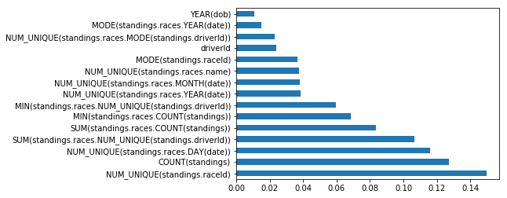

```python
feat_importances = pd.Series(model.feature_importances_, index=train_X.columns)
feat_importances.nlargest(15).plot(kind='barh')
plt.show()
```

```python
feature_matrix.columns
```

```
Index(['driverId', 'nationality', 'COUNT(standings)',
       'NUM_UNIQUE(standings.raceId)', 'MODE(standings.raceId)', 'DAY(dob)',
       'YEAR(dob)', 'MONTH(dob)', 'WEEKDAY(dob)',
       'NUM_UNIQUE(standings.races.name)', 'MODE(standings.races.name)',
       'SUM(standings.races.COUNT(standings))',
       'SUM(standings.races.NUM_UNIQUE(standings.driverId))',
       'STD(standings.races.COUNT(standings))',
       'STD(standings.races.NUM_UNIQUE(standings.driverId))',
       'MAX(standings.races.COUNT(standings))',
       'MAX(standings.races.NUM_UNIQUE(standings.driverId))',
       'SKEW(standings.races.COUNT(standings))',
       'SKEW(standings.races.NUM_UNIQUE(standings.driverId))',
       'MIN(standings.races.COUNT(standings))',
       'MIN(standings.races.NUM_UNIQUE(standings.driverId))',
       'MEAN(standings.races.COUNT(standings))',
       'MEAN(standings.races.NUM_UNIQUE(standings.driverId))',
       'NUM_UNIQUE(standings.races.MODE(standings.driverId))',
       'NUM_UNIQUE(standings.races.DAY(date))',
       'NUM_UNIQUE(standings.races.YEAR(date))',
       'NUM_UNIQUE(standings.races.MONTH(date))',
       'NUM_UNIQUE(standings.races.WEEKDAY(date))',
       'MODE(standings.races.MODE(standings.driverId))',
       'MODE(standings.races.DAY(date))', 'MODE(standings.races.YEAR(date))',
       'MODE(standings.races.MONTH(date))',
       'MODE(standings.races.WEEKDAY(date))', 'target'],
      dtype='object')
```